# Visualizing and Analyzing Temporal Data

Fundamentals of Data Science

MTH-391A | Spring 2025 | University of Portland

March 14, 2025

# Objectives

- **Know how to visualize time-series in multiple ways**
- **Develop an understanding on how different time-series visualizations affect interpretation.**
- **Activity: Visualize and Interpret Time-Series**

# Previously… (1/2)

**Date/Time Ambiguity and Formats**

**Example Dates**

```r
# year-month-day
ymd("2017-01-31")
```

```
## [1] "2017-01-31"
```

```r
# month-day-year
mdy("January 31st, 2017")
```

```
## [1] "2017-01-31"
```

```r
# day-month-year
dmy("31-Jan-2017")
```

```
## [1] "2017-01-31"
```

**Converting String Dates into date/time format**

- Identify the order in which year, month, and day appear in your dates
- Arrange “y”, “m”, and “d” in the same order
- That gives you the name of the function that will parse your date into the [ISO8601](https://www.iso.org/iso-8601-date-and-time-format.html), an international standard for writing date/time.

# Previously… (2/2)

**Time Granularity and Time-Zones**

- **Granularity Matters:** The level of detail or precision used to represent time in a given context
  - Seconds, minutes, hours, days, weeks, months, years, decades, etc.
  - Semesters (fall, spring)
  - Seasons (winter, spring, summer, fall)
  - TV Show seasons or movie sequels
  - Election cycles
- **Time Zones Shift Meaning:** Be mindful of time-zones
  - A “morning sale” in New York City, USA isn’t morning in Manila, Philippines

# Case Study I

**New York City Flights**

- The `nycflights13` package: On-time data for all flights that departed NYC (i.e. JFK, LGA or EWR) in 2013
- The `nycflights23` package: Similar to `nycflights13` but in 2023

**Load Packages**

```r
library(nycflights13)
library(nycflights23)
```

**Data Frames**

```r
# bind the two data frames
flights <- nycflights13::flights %>%
  rbind(nycflights23::flights)

# show size
dim(flights)
```

```
## [1] 772128     19
```

# Variables of Interest

Each row in the `flights` tibble is a unique flight from NYC.

- `date_time` | date and time of departure, which can be decomposed into parts (`year`, `month`, `day`, `hour`)
- `carrier` | type of airline
- `origin` | origin airport in New York (JFK, LGA or EWR)
- `dest` | destination airport (e.g. ATL, LAX, PDX)
- `dep_delay` | Departure delays, in minutes. Negative times represent early departures/arrivals.

```r
# view random sample
flights_sub |>
  sample_n(3)
```

```
## # A tibble: 3 × 9
##   date_time           carrier origin dest  dep_delay  year month   day  hour
##   <dttm>              <chr>   <chr>  <chr>     <dbl> <int> <int> <int> <dbl>
## 1 2013-11-07 06:00:00 WN      LGA    ATL           0  2013    11     7     6
## 2 2013-10-30 12:00:00 AA      JFK    BOS           2  2013    10    30    12
## 3 2023-08-24 21:00:00 9E      LGA    PWM          34  2023     8    24    21
```

# How to Get Started on Exploring Temporal Data

The main **goal of time-series data** is to analyze how a variable or set of variables evolve over time. This typically involves identifying patterns and trends.

**How many flights occurred in 2013 and 2023?**

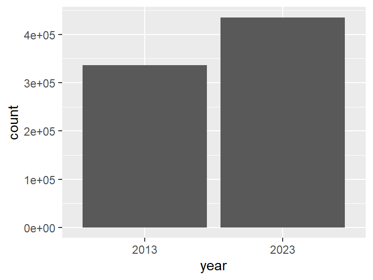

# Increase Granularity

**What is the number of fights per month?**

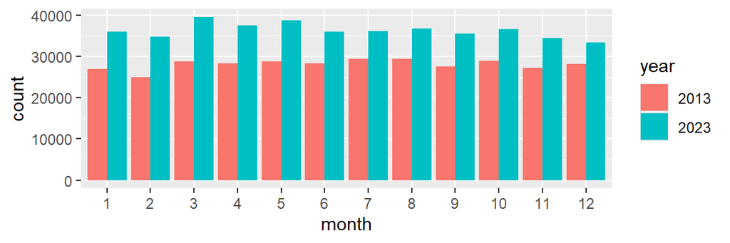

# Incorporate Other Variables

**What is median departure delay per month coming out of each NYC airport?**

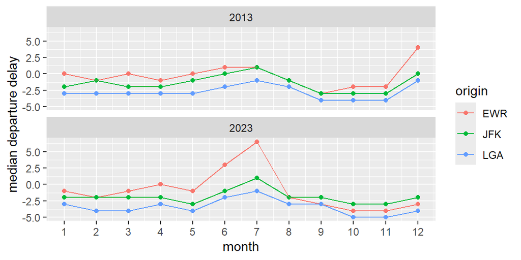

# More Precision

**What is the median daily delay during the summer months?**

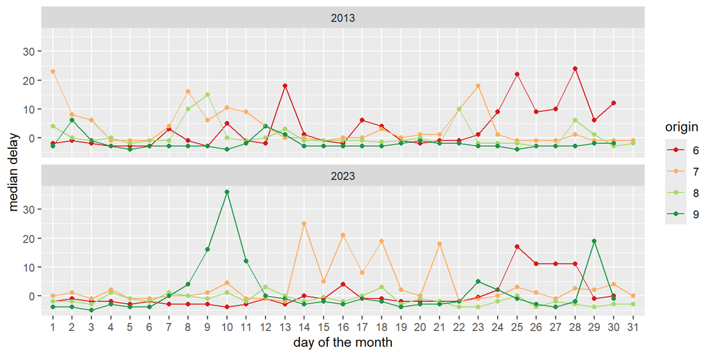

# A Stragety on Visualizing Time-Series Data

**Effective Methods for Analyzing Trends Over Time**

1. **Define the Objective**
- What insights are you looking for?
- Are you analyzing trends, seasonality, anomalies, or forecasting?
2. **Choose the Right Visualization Type**
- Line graphs: Best for continuous trends over time
- Bar Plots: Good for comparing discrete time intervals
- Boxplots: Helps visualizing distributions for comparing discrete time intervals
3. **Data Preprocessing**
- Handle missing values.
- Aggregate data to appropriate time intervals (hourly, daily, monthly).
- Normalize or scale data if necessary.
4. **Enhance Readability**
- Use consistent time intervals on the x-axis.
- Add annotations for significant events.
- Utilize color coding for multiple time series.

# Activity: Visualize Time-Series

1. Log-in to Posit Cloud and open the R Studio assignment *MA15: Visualize Time-Series*.
2. Make sure you are in the current working directory. Rename the `.Rmd` file by replacing `[name]` with your name using the format `[First name][Last initial]`. Then, open the `.Rmd` file.
3. Change the author in the YAML header.
4. Read the provided instructions.
5. Answer all exercise problems on the designated sections.